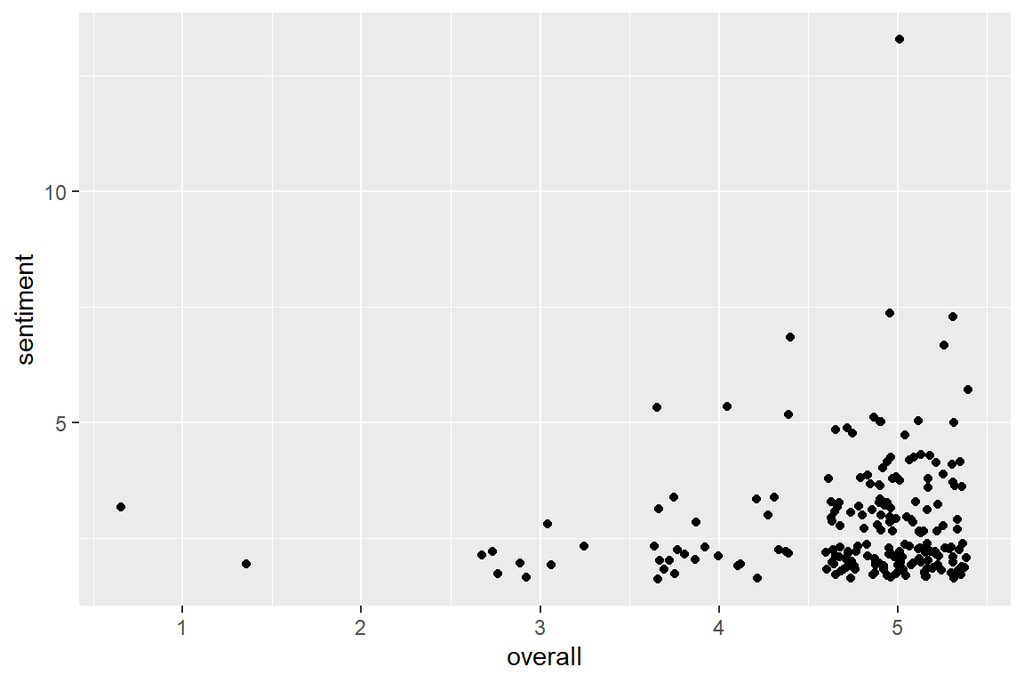

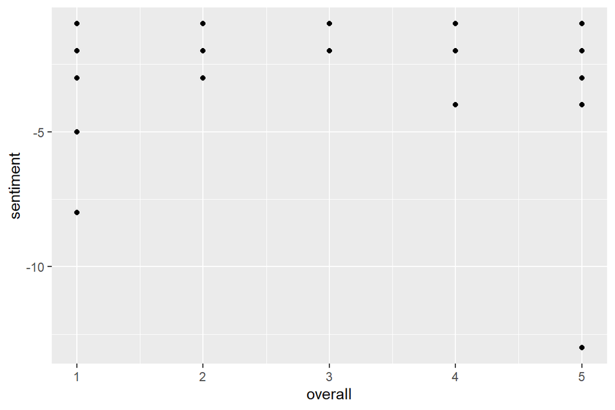

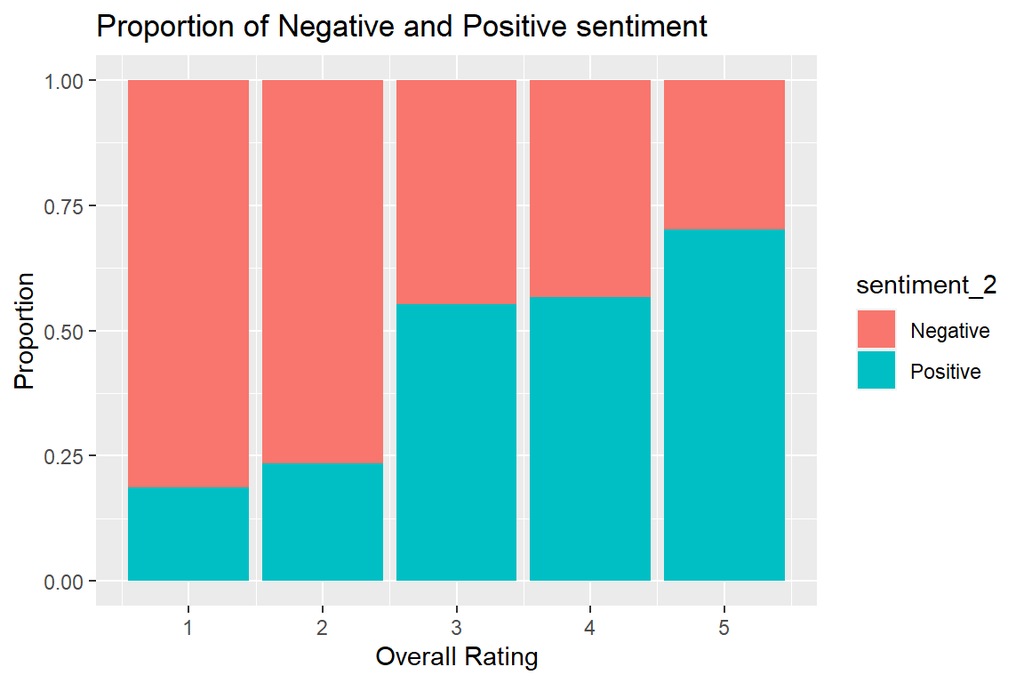

Finally, we plot the words against their occurance, based on their contributions to the sentiment.

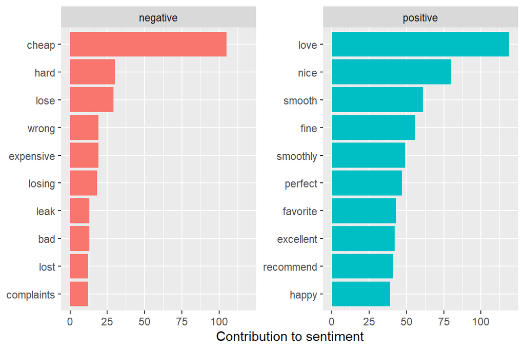

The word `cheap` contributes the most to negative reviews and the word `love` contributes most to the positive reviews.

Conducting the analysis, one can safely say that the price and user’s experience contribute greatly to the sentiment of a customer’s review. If a customer’s purchase contains itms that tend to be defective, their review is going to be more negative.

On the other hand, most of the reviews are positive, with a rating between four and five stars. The words in the convetributing to a positive sentiment depict a positive user experience. The user also tends to recommend the product to other potential users if they have a positive experience.